# Notebook 14 – Solutions

## Getting Started

Before running this notebook, select “Session > Restart R and Clear Output” in the menu above to start a new R session. This will clear any old data sets and give us a blank slate to start with.

Note that the questions today are a bit more open ended than in previous notebooks.

## Qu’ran Surah

We are going to use an API today that gives information about the Qu’ran. The text is broken up into 114 surah (similar to Chapters). We can get metadata about each of the surah by using an API defined as follows:

- protocol: **http**
- authority: **api.alquran.cloud**
- path: **v1/surah**

There are no query parameters needed for this API call. In the block below, call this API using a cache directory and save the results of the parsed JSON data as an object named `obj`:

```r
url_base <- modify_url("http://api.alquran.cloud/v1/surah")
res <- http_cache_get(url_base, cache_dir = "cache")
obj <- content(res, type = "application/json")
```

Now, in the next block, create a tabular dataset containing as much information as possible from the object. Use the techniques we saw today to figure out the returned objects structure:

```r
# obj$data[[1]]   # note: this is a helpful object to look at

surah <- tibble(
  number = map_int(obj$data, ~ .x$number),
  name = map_chr(obj$data, ~ .x$name),
  english_name = map_chr(obj$data, ~ .x$englishName),
  english_trans = map_chr(obj$data, ~ .x$englishNameTranslation),
  ayah_count = map_int(obj$data, ~ .x$numberOfAyahs),
  rev_type = map_chr(obj$data, ~ .x$revelationType)
)

surah
```

```
## # A tibble: 114 × 6
##    number name          english_name english_trans        ayah_count rev_type
##     <int> <chr>         <chr>        <chr>                     <int> <chr>
##  1      1 سُورَةُ ٱلْفَاتِحَةِ  Al-Faatiha   The Opening                   7 Meccan
##  2      2 سُورَةُ البَقَرَةِ   Al-Baqara    The Cow                     286 Medinan
##  3      3 سُورَةُ آلِ عِمۡرَانَ Aal-i-Imraan The Family of Imraan        200 Medinan
##  4      4 سُورَةُ النِّسَاءِ   An-Nisaa     The Women                   176 Medinan
##  5      5 سُورَةُ المَائـِدَةِ Al-Maaida    The Table                   120 Medinan
##  6      6 سُورَةُ الأَنۡعَامِ  Al-An'aam    The Cattle                  165 Meccan
##  7      7 سُورَةُ الأَعۡرَافِ  Al-A'raaf    The Heights                 206 Meccan
##  8      8 سُورَةُ الأَنفَالِ  Al-Anfaal    The Spoils of War            75 Medinan
##  9      9 سُورَةُ التَّوۡبَةِ   At-Tawba     The Repentance              129 Medinan
## 10     10 سُورَةُ يُونُسَ     Yunus        Jonas                       109 Meccan
## # … with 104 more rows
```

Make a plot that shows the surah number on the x-axis and the ayah (verse) count on the y-axis. Color the points based on the revelation type (either Meccan or Medinian). Take note of any patterns in the way the surah are ordered.

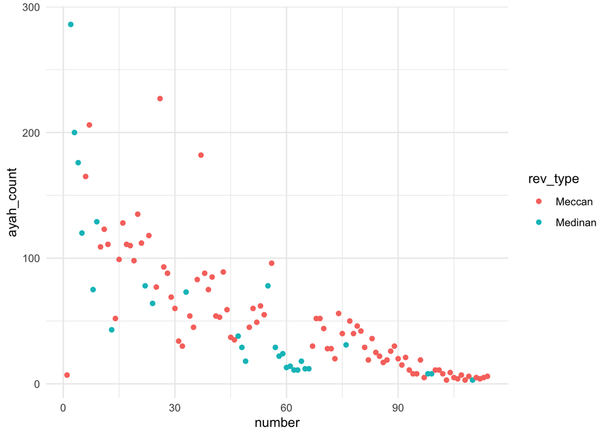

```r
surah %>%
  ggplot(aes(number, ayah_count)) +
    geom_point(aes(color = rev_type))
```

## Qu’ran Surah Text

The same service that we used above also provides the text of individual surah. This can be done with the HTTP API using the following parameter, where # is replaced by the surah number.

- protocol: **http**
- authority: **api.alquran.cloud**
- path: **v1/surah/#/en.asad**

In the code below, grab the data for of the 2nd surah (“The Cow”) using this API and save the result of the parsed JSON data as `obj`:

```r
url_base <- modify_url("http://api.alquran.cloud/v1/surah/2/en.asad")
res <- http_cache_get(url_base, cache_dir = "cache")
obj <- content(res, type = "application/json")
```

Again, create a tabular dataset out of `obj`, storing as much information as possible.

```r
surah_txt <- tibble(
  number = obj$data$number,
  name = obj$data$name,
  english_name = obj$data$englishName,
  english_trans = obj$data$englishNameTranslation,
  ayah_count = obj$data$numberOfAyahs,
  rev_type = obj$data$revelationType,
  edition_id = obj$data$edition$identifier,
  ayah_num = map_int(obj$data$ayahs, ~ .x$number),
  text = map_chr(obj$data$ayahs, ~ .x$text),
  juz = map_int(obj$data$ayahs, ~ .x$juz),
  manzil = map_int(obj$data$ayahs, ~ .x$manzil),
  page = map_int(obj$data$ayahs, ~ .x$page),
  ruku = map_int(obj$data$ayahs, ~ .x$ruku),
  hizb_quarter = map_int(obj$data$ayahs, ~ .x$hizbQuarter),
  sajda = map_lgl(obj$data$ayahs, ~ .x$sajda)
)

surah_txt %>%
  select(number, text)
```

```
## # A tibble: 286 × 2
##    number text
##     <int> <chr>
##  1      2 "Alif. Lam. Mim."
##  2      2 "THIS DIVINE WRIT - let there be no doubt about it is [meant to be] a guid…
##  3      2 "Who believe in [the existence of] that which is beyond the reach of human…
##  4      2 "And who believe in that which has been bestowed from on high upon thee, […
##  5      2 "It is they who follow the guidance [which comes from their Sustainer; and…
##  6      2 "BEHOLD, as for those who are bent on denying the truth - it is all one to…
##  7      2 "God; has sealed their hearts and their hearing, and over their eyes is a …
##  8      2 "And there are people who say, \"We do believe in God and the Last Day,\" …
##  9      2 "They would deceive God and those who have attained to faith-the while the…
## 10      2 "In their hearts is disease, and so God lets their disease increase; and g…
## # … with 276 more rows
```

There is not, yet, much we can do in terms of analysis with the text directly. We will return to this task in the coming weeks.